# Applied Multivariate Ananlysis_Final Project

박선, 황성윤

2020 12 20

```r
library(readr)
library(dplyr)
```

### 다음 자료는 우리나라 시도별 산업별 종사자 수에 대한 통계청(KOSIS)의 자료이다. 다음 물음에 답하시오(박선, 황성윤)

*참고: [2018년 시도·산업·종사자규모별 사업체수, 종사자수](https://kosis.kr/statHtml/statHtml.do?orgId=101&tblId=DT_1K52C03&vw_cd=MT_ZTITLE&list_id=K22_4&seqNo=&lang_mode=ko&language=kor&obj_var_id=&itm_id=&conn_path=MT_ZTITLE/)*

(단, 각시도의 각 11개의 산업별 종사자 수는 각 시도의 20세 이상의 총 인원수로 나누어서 분석할 것)

#### **데이터 불러오기**

```r
setwd("C:/Users/Park sun/Desktop/2020-12-20 다변량 분석")
workers <- read.csv("workers.csv")

str(workers)
```

```
## 'data.frame':    3063 obs. of  5 variables:
##  $ 행정구역별   : chr  "전국" "전국" "전국" "전국" ...
##  $ 산업별       : chr  "전체 산업" "전체 산업" "전체 산업" "전체 산업" ...
##  $ 종사자규모별 : chr  "계" "1 - 4명" "5 - 9명" "10 - 19명" ...
##  $ 사업체수..개.: int  4103172 3274152 491200 186654 100961 31235 14907 2092 1275 696 ...
##  $ 종사자수..명.: chr  "22234776" "5878444" "3157255" "2459688" ...
```

```r
summary(workers)
```

```
##   행정구역별           산업별          종사자규모별       사업체수..개.
##  Length:3063        Length:3063        Length:3063        Min.   :      1
##  Class :character   Class :character   Class :character   1st Qu.:     13
##  Mode  :character   Mode  :character   Mode  :character   Median :    124
##                                                           Mean   :  10717
##                                                           3rd Qu.:   1227
##                                                           Max.   :4103172
##  종사자수..명.
##  Length:3063
##  Class :character
##  Mode  :character
##
##
##
```

#### **데이터 구조 확인 및 전처리**

```r
names(workers) <- c("district","industry","workers_grp","inds_num","work_num")  #분석에 용이하게 영문으로 변수명 수정
```

- 분석에 용이하도록 변수명을 영어로 변경한다.

| 변수(국문명) | 변수(영문명) |
| --- | --- |
| 행정구역별 | district |
| 산업별 | industry |
| 종사자규모별 | workers_grp |
| 사업체수(개) | inds_num |
| 종사자수(명) | work_num |

```r
workers$district <- as.factor(workers$district)    # 데이터 정보에 적합하게 변수 타입 수정
workers$industry <- as.factor(workers$industry)
workers$workers_grp <- as.factor(workers$workers_grp)
workers$work_num <- as.numeric(workers$work_num)
table(workers$district)   #범주형 변수에 대해 각 수준별로 빈도수 확인
```

```
##
## 강원 경기 경남 경북 광주 대구 대전 부산 서울 세종 울산 인천 전국 전남 전북 제주
##  169  183  171  163  167  168  168  175  184  150  168  176  197  167  166  161
## 충남 충북
##  165  165
```

```r
workers <-subset(workers,workers$district!="전국")
```

```r
# table(workers$industry)
workers <-subset(workers,workers$industry!="전체 산업")
workers$industry <- as.factor(substr(workers$industry, 1, unlist(gregexpr(pattern ='\\(',workers$industry))-1))
table(workers$industry)
```

```
##
##                                    건설업
##                                       161
##           공공행정, 국방 및 사회보장 행정
##                                       169
##                                      광업
##                                        92
##                             교육 서비스업
##                                       168
##                            금융 및 보험업
##                                       137
##                        농업, 임업 및 어업
##                                       107
##                            도매 및 소매업
##                                       139
##               보건업 및 사회복지 서비스업
##                                       168
##                                  부동산업
##                                       132
## 사업시설 관리, 사업 지원 및 임대 서비스업
##                                       162
##    수도, 하수 및 폐기물 처리, 원료 재생업
##                                       120
##                          숙박 및 음식점업
##                                       135
##         예술, 스포츠 및 여가관련 서비스업
##                                       134
##                            운수 및 창고업
##                                       150
##       전기, 가스, 증기 및 공기조절 공급업
##                                       138
##               전문, 과학 및 기술 서비스업
##                                       154
##                                정보통신업
##                                       138
##                                    제조업
##                                       167
##  협회 및 단체, 수리 및 기타 개인 서비스업
##                                       125
```

```r
length(levels(workers$industry))
```

```
## [1] 19
```

- 산업별 종사자수를 확인해보면 다음과 같다. 총 19개의 산업으로 구분되어있다.
- 산업 구분이 **전체 산업**인 경우는 분석에서 제외한다.
- 단, 분석에 용이하도록 괄호 안 산업 코드는 삭제한다.

```r
table(workers$workers_grp)
```

```
##
##     1 - 4명   10 - 19명 100 - 299명 1000명 이상   20 - 49명 300 - 499명
##         323         319         297         123         319         202
##     5 - 9명   50 - 99명 500 - 999명          계
##         323         304         163         323
```

```r
workers <-subset(workers,workers$workers_grp!="계")
workers <- within(workers, {
                workers_grp_new = character(0)
                workers_grp_new[workers_grp=="1000명 이상"] = "A"
                workers_grp_new[workers_grp=="500 - 999명"] = "B"
                workers_grp_new[workers_grp=="300 - 499명"] = "C"
                workers_grp_new[workers_grp=="100 - 299명"] = "D"
                workers_grp_new[workers_grp=="50 - 99명"] = "E"
                workers_grp_new[workers_grp=="20 - 49명"] = "F"
                workers_grp_new[workers_grp=="10 - 19명"] = "G"
                workers_grp_new[workers_grp=="5 - 9명"] = "H"
                workers_grp_new[workers_grp=="1 - 4명"] = "I"
                workers_grp_new = factor(workers_grp_new)
})
workers <- workers[,-3]
head(workers)
```

```
##     district           industry inds_num work_num workers_grp_new
## 209     서울 농업, 임업 및 어업       17       37               I
## 210     서울 농업, 임업 및 어업        4       22               H
## 211     서울 농업, 임업 및 어업        3       49               G
## 212     서울 농업, 임업 및 어업        4       99               F
## 213     서울 농업, 임업 및 어업        2       NA               D
## 215     서울               광업       20       40               I
```

- 종사자 규모별 종사자수를 확인해보면 다음과 같다. 종사자의 규모는 총 9등급으로 구분하였다.
- 종사자 규모가 **계**인 경우는 분석에서 제외한다.
- 분석이 용이하도록 규모별로 등급을 나눈 후 `workers_grp_new` 변수로 저장한다. 등급은 아래와 같다.

| 종사자 규모 | 등급 |
| --- | --- |
| 1000명 이상 | A |
| 500 - 999명 | B |
| 300 - 499명 | C |
| 100 - 299명 | D |
| 50 - 99명 | E |
| 20 - 49명 | F |
| 10 - 19명 | G |
| 5 - 9명 | H |
| 1 - 4명 | I |

```r
summary(workers[,c(3,4)])  #수치형 변수에 대해 각 변수별 요약 정리
```

```
##     inds_num         work_num
##  Min.   :     1   Min.   :     6
##  1st Qu.:     8   1st Qu.:  1266
##  Median :    62   Median :  3682
##  Mean   :  1729   Mean   : 10602
##  3rd Qu.:   410   3rd Qu.:  9787
##  Max.   :187982   Max.   :347210
##                   NA's   :300
```

```r
sum(is.na(workers)) ##Na 개수 확인하기
```

```
## [1] 300
```

- 수치형 변수인 `inds_num`와 `work_num`를 요약해보면 위와 같다.
- `work_num`변수에 결측치가 300개 있음을 확인 할 수 있다.

#### **파생 변수 생성**

- 각시도의 각 11개의 산업별 종사자 수는 각 시도의 20세 이상의 총 인원수로 나누어서 분석할 것
- 각 시도의 20세 이상 인구수를 확인하기 위해 [2018년 기준 주민등록 인구통계](https://jumin.mois.go.kr/#)를 참고하였다.
- 경제활동 인구를 **20세~ 69세**로 가정하고 분석을 실시하였다.

```r
age_district <- read_csv("C:/Users/Park sun/Desktop/2020-12-20 다변량 분석/age_district.csv")  # 2018년도 각 시도별 인구수 확인
# str(age_district)
age_new <- age_district[,c(1,6:10)]
names(age_new) <- c("district","20~29","30~39","40~49","50~59","60~69")
```

```r
age_new <-subset(age_new,age_new$district!="전국  (0000000000)")
# population <- apply(age_new[,-1],1,sum)
# data2 <- tibble(district=age_new$district,
                # population=population)
age_new2 <- within(age_new,{district[district=="서울특별시  (1100000000)"] = "서울"
            district[age_new$district=="부산광역시  (2600000000)"] = "부산"
            district[age_new$district=="대구광역시  (2700000000)"] = "대구"
            district[age_new$district=="인천광역시  (2800000000)"] = "인천"
            district[age_new$district=="광주광역시  (2900000000)"] = "광주"
            district[age_new$district=="대전광역시  (3000000000)"] = "대전"
            district[age_new$district=="울산광역시  (3100000000)"] = "울산"
            district[age_new$district=="세종특별자치시  (3600000000)"] = "세종"
            district[age_new$district=="경기도  (4100000000)"] = "경기"
            district[age_new$district=="강원도  (4200000000)"] = "강원"
            district[age_new$district=="충청북도  (4300000000)"] = "충북"
            district[age_new$district=="충청남도  (4400000000)"] = "충남"
            district[age_new$district=="전라북도  (4500000000)"] = "전북"
            district[age_new$district=="전라남도  (4600000000)"] = "전남"
            district[age_new$district=="경상북도  (4700000000)"] = "경북"
            district[age_new$district=="경상남도  (4800000000)"] = "경남"
            district[age_new$district=="제주특별자치도  (5000000000)"] = "제주"
            })
```

```r
population <- apply(age_new2[,-1],1,sum)
data2 <- tibble(district=as.factor(age_new2$district),
                population=population)
data2
```

```
## # A tibble: 17 x 2
##    district population
##    <fct>         <dbl>
##  1 서울        7278303
##  2 부산        2507811
##  3 대구        1776986
##  4 인천        2167447
##  5 광주        1029119
##  6 대전        1074785
##  7 울산         849402
##  8 세종         213293
##  9 경기        9425735
## 10 강원        1071247
## 11 충북        1120650
## 12 충남        1455189
## 13 전북        1243512
## 14 전남        1249245
## 15 경북        1852176
## 16 경남        2372505
## 17 제주         460821
```

- `district`가 전국인 행은 제외해주고 각각의 시도를 `workers` 데이터셋의 `distrinct`와 통일 시켜주었다.

```r
workers_new <- left_join(workers, data2, by = "district")
workers_new$prob.work_num = round(workers_new$work_num/workers_new$population*100,3)
workers_new<-workers_new[,-6]
```

- 각각의 시도별 20세~69세 인구 수로 종사자 수 나눠 비율을 계산한 후 `workers_new` 데이터 셋을 생성 하여 `prob.work_num`변수를 생성하였다.

```r
sum(is.na(workers_new$prob.work_num))
```

```
## [1] 300
```

```r
workers_new<-workers_new[!is.na(workers_new$prob.work_num),]
```

- 결측치를 확인하여 결측치는 삭제 처리하였다.
- 최종 데이터는 아래와 같다.

```r
head(workers_new)
```

```
##   district           industry inds_num work_num workers_grp_new prob.work_num
## 1     서울 농업, 임업 및 어업       17       37               I         0.001
## 2     서울 농업, 임업 및 어업        4       22               H         0.000
## 3     서울 농업, 임업 및 어업        3       49               G         0.001
## 4     서울 농업, 임업 및 어업        4       99               F         0.001
## 6     서울               광업       20       40               I         0.001
## 7     서울               광업        3       19               H         0.000
```

```r
str(workers_new)
```

```
## 'data.frame':    2073 obs. of  6 variables:
##  $ district       : Factor w/ 18 levels "강원","경기",..: 9 9 9 9 9 9 9 9 9 9 ...
##  $ industry       : Factor w/ 19 levels "건설업","공공행정, 국방 및 사회보장 행정",..: 6 6 6 6 3 3 18 18 18 18 ...
##  $ inds_num       : int  17 4 3 4 20 3 44106 10942 2477 1106 ...
##  $ work_num       : num  37 22 49 99 40 ...
##  $ workers_grp_new: Factor w/ 9 levels "A","B","C","D",..: 9 8 7 6 9 8 9 8 7 6 ...
##  $ prob.work_num  : num  0.001 0 0.001 0.001 0.001 ...
```

### (1) 산업별 종사자 비율에 의해 각 시도를 요인분석을 통해 분류하시오.

*먼저, 분석에 적절한 형태로 데이터를 변환 시켜준다.

```r
library(reshape2)
```

```r
workers_1 <- dcast(workers_new[,c("industry","district","prob.work_num")],
                   industry~district,fun.aggregate = sum)
head(workers_1)
```

```
##                          industry  강원  경기  경남  경북  광주  대구  대전
## 1                          건설업 5.304 2.985 3.439 4.026 5.405 3.296 3.442
## 2 공공행정, 국방 및 사회보장 행정 3.576 1.265 2.037 2.482 1.454 1.692 2.468
## 3                            광업 0.215 0.016 0.029 0.067 0.003 0.000 0.000
## 4                   교육 서비스업 5.331 4.073 4.001 4.312 4.611 4.387 5.391
## 5                  금융 및 보험업 1.713 1.102 1.446 1.399 2.242 1.794 1.948
## 6              농업, 임업 및 어업 0.272 0.051 0.133 0.247 0.025 0.002 0.001
##    부산  서울  세종  울산  인천  전남  전북  제주  충남  충북
## 1 4.003 5.213 2.492 4.286 2.562 5.566 3.916 4.515 3.690 4.304
## 2 1.813 1.925 8.878 1.456 1.699 3.207 2.414 3.066 2.049 2.412
## 3 0.003 0.001 0.015 0.031 0.019 0.211 0.073 0.032 0.049 0.092
## 4 4.072 4.756 5.281 3.672 3.249 4.331 4.866 3.958 4.651 4.399
## 5 2.046 3.604 0.704 1.493 1.184 1.706 1.839 1.779 1.311 1.404
## 6 0.126 0.003 0.017 0.017 0.009 0.533 0.252 0.540 0.291 0.200
```

**상관계수 확인하기**

```r
library(corrgram)
```

```r
round(cor(workers_1[,-1]),2)
```

```
##      강원 경기 경남 경북 광주 대구 대전 부산 서울 세종 울산 인천 전남 전북 제주
## 강원 1.00 0.70 0.68 0.69 0.90 0.85 0.90 0.88 0.69 0.67 0.59 0.75 0.91 0.89 0.93
## 경기 0.70 1.00 0.98 0.98 0.88 0.95 0.79 0.90 0.53 0.71 0.97 0.98 0.90 0.92 0.50
## 경남 0.68 0.98 1.00 1.00 0.85 0.92 0.71 0.86 0.40 0.73 0.99 0.97 0.89 0.90 0.46
## 경북 0.69 0.98 1.00 1.00 0.85 0.92 0.71 0.85 0.39 0.75 0.99 0.97 0.90 0.91 0.46
## 광주 0.90 0.88 0.85 0.85 1.00 0.97 0.93 0.98 0.74 0.63 0.78 0.90 0.97 0.98 0.74
## 대구 0.85 0.95 0.92 0.92 0.97 1.00 0.90 0.98 0.67 0.70 0.87 0.96 0.97 0.99 0.68
## 대전 0.90 0.79 0.71 0.71 0.93 0.90 1.00 0.93 0.86 0.65 0.63 0.80 0.88 0.91 0.79
## 부산 0.88 0.90 0.86 0.85 0.98 0.98 0.93 1.00 0.75 0.64 0.79 0.93 0.96 0.96 0.76
## 서울 0.69 0.53 0.40 0.39 0.74 0.67 0.86 0.75 1.00 0.32 0.33 0.52 0.62 0.64 0.71
## 세종 0.67 0.71 0.73 0.75 0.63 0.70 0.65 0.64 0.32 1.00 0.69 0.72 0.74 0.73 0.46
## 울산 0.59 0.97 0.99 0.99 0.78 0.87 0.63 0.79 0.33 0.69 1.00 0.95 0.83 0.84 0.35
## 인천 0.75 0.98 0.97 0.97 0.90 0.96 0.80 0.93 0.52 0.72 0.95 1.00 0.93 0.94 0.56
## 전남 0.91 0.90 0.89 0.90 0.97 0.97 0.88 0.96 0.62 0.74 0.83 0.93 1.00 0.99 0.73
## 전북 0.89 0.92 0.90 0.91 0.98 0.99 0.91 0.96 0.64 0.73 0.84 0.94 0.99 1.00 0.71
## 제주 0.93 0.50 0.46 0.46 0.74 0.68 0.79 0.76 0.71 0.46 0.35 0.56 0.73 0.71 1.00
## 충남 0.64 0.98 1.00 1.00 0.82 0.90 0.68 0.83 0.37 0.73 0.99 0.96 0.86 0.88 0.41
## 충북 0.67 0.98 1.00 1.00 0.84 0.91 0.70 0.84 0.39 0.74 0.99 0.97 0.88 0.89 0.43
##      충남 충북
## 강원 0.64 0.67
## 경기 0.98 0.98
## 경남 1.00 1.00
## 경북 1.00 1.00
## 광주 0.82 0.84
## 대구 0.90 0.91
## 대전 0.68 0.70
## 부산 0.83 0.84
## 서울 0.37 0.39
## 세종 0.73 0.74
## 울산 0.99 0.99
## 인천 0.96 0.97
## 전남 0.86 0.88
## 전북 0.88 0.89
## 제주 0.41 0.43
## 충남 1.00 1.00
## 충북 1.00 1.00
```

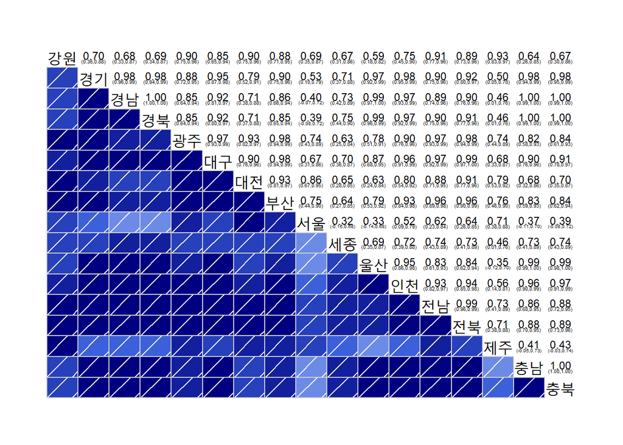

```r
corrgram(workers_1[,-1],upper.panel = panel.conf)
```

- 각 시도별 상관계수를 확인해보면 위와 같다. 위 그림은 상관계수를 도식화한 그림이다.

**요인분석 수행**

```r
library(psych)
```

```r
work.factor <- principal(workers_1[,-1], rotate="none")
work.factor$values
```

```
##  [1] 1.394165e+01 1.929417e+00 5.524782e-01 3.303765e-01 1.239443e-01
##  [6] 5.166442e-02 4.157372e-02 1.148609e-02 7.826043e-03 4.890510e-03
## [11] 1.988766e-03 1.789524e-03 4.346533e-04 2.480325e-04 1.380977e-04
## [16] 8.780168e-05 1.009965e-05
```

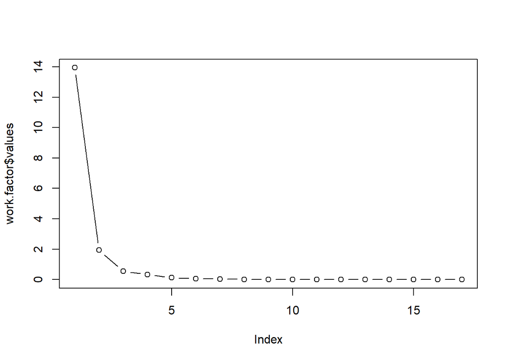

```r
plot(work.factor$values, type="b")
```

- 각 시도 변수로 하여 유사한 시도를 묶어 새로운 잠재 요인으로 결정하기 위해 요인분석을 실시하였다. 결과는 위와 같다.
- *value*는 고유근을 말하고, 고유근이 1이상의 경우에만 인자수로 채택한다. 따라서 2까지가 1이 넘기 때문에 2개까지만 선택하는 것이 바람직하다고 보인다. 그러나 정보가 적기 때문에 본 분석에서는 요인의 수를 3으로 선택한다.

### (2) 요인분석을 한 후 요인에 적절한 이름을 부여하시오.

```r
work.factor2 = principal(workers_1[,-1], nfactors = 3,rotate="none")
work.factor2
```

```
## Principal Components Analysis
## Call: principal(r = workers_1[, -1], nfactors = 3, rotate = "none")
## Standardized loadings (pattern matrix) based upon correlation matrix
##       PC1   PC2   PC3   h2     u2 com
## 강원 0.86  0.42  0.24 0.97 0.0285 1.6
## 경기 0.96 -0.22 -0.13 0.99 0.0117 1.1
## 경남 0.95 -0.32 -0.02 1.00 0.0043 1.2
## 경북 0.95 -0.32  0.00 1.00 0.0039 1.2
## 광주 0.96  0.19 -0.10 0.97 0.0282 1.1
## 대구 0.99  0.05 -0.08 0.99 0.0100 1.0
## 대전 0.89  0.39 -0.04 0.95 0.0523 1.4
## 부산 0.97  0.18 -0.11 0.98 0.0218 1.1
## 서울 0.63  0.63 -0.31 0.90 0.0999 2.4
## 세종 0.76 -0.14  0.54 0.88 0.1178 1.9
## 울산 0.90 -0.42 -0.07 0.99 0.0115 1.4
## 인천 0.97 -0.16 -0.07 0.98 0.0202 1.1
## 전남 0.98  0.08  0.07 0.97 0.0337 1.0
## 전북 0.98  0.08  0.02 0.97 0.0251 1.0
## 제주 0.68  0.63  0.21 0.90 0.0970 2.2
## 충남 0.93 -0.37 -0.04 0.99 0.0059 1.3
## 충북 0.94 -0.34 -0.02 1.00 0.0045 1.3
##
##                         PC1  PC2  PC3
## SS loadings           13.94 1.93 0.55
## Proportion Var         0.82 0.11 0.03
## Cumulative Var         0.82 0.93 0.97
## Proportion Explained   0.85 0.12 0.03
## Cumulative Proportion  0.85 0.97 1.00
##
## Mean item complexity =  1.4
## Test of the hypothesis that 3 components are sufficient.
##
## The root mean square of the residuals (RMSR) is  0.02
##  with the empirical chi square  1.68  with prob <  1
##
## Fit based upon off diagonal values = 1
```

- **h2**: 각 변수(시도)의 공통성(communality), 다른 변수들과의 공통성을 말하는 것으로 저 수치가 통상 0.3 보다 아래이면 다른 변수들과 공통점이 별로 없는 것으로 판단
- **u2**: 각 변수(시도)의 고유분산
- **Proportion var**: 각 요인이 설명 하는 총 분산의 비율을 말하는 것으로 RC1이 총 분산의 82%, RC2가 11.3%, RC3가 3%로 이 세 요인으로 총 변동의 96.6%를 설명한다 해석할 수 있다.
- RC1과, RC2, RC3의 수치를 확인해보면 모든 경우에서 RC1의 값이 가장 큰 것으로 보아 해당 요인분석은 바람직하게 수행됐다고 보기 어렵다. 따라서 요인 회전을 통해 분산을 재분배 시키는 작업을 실시해야하는 것으로 보이고 각 요인에 대한 이름을 붙이기 위해서는 더 많은 정보가 필요한 것으로 판단된다.

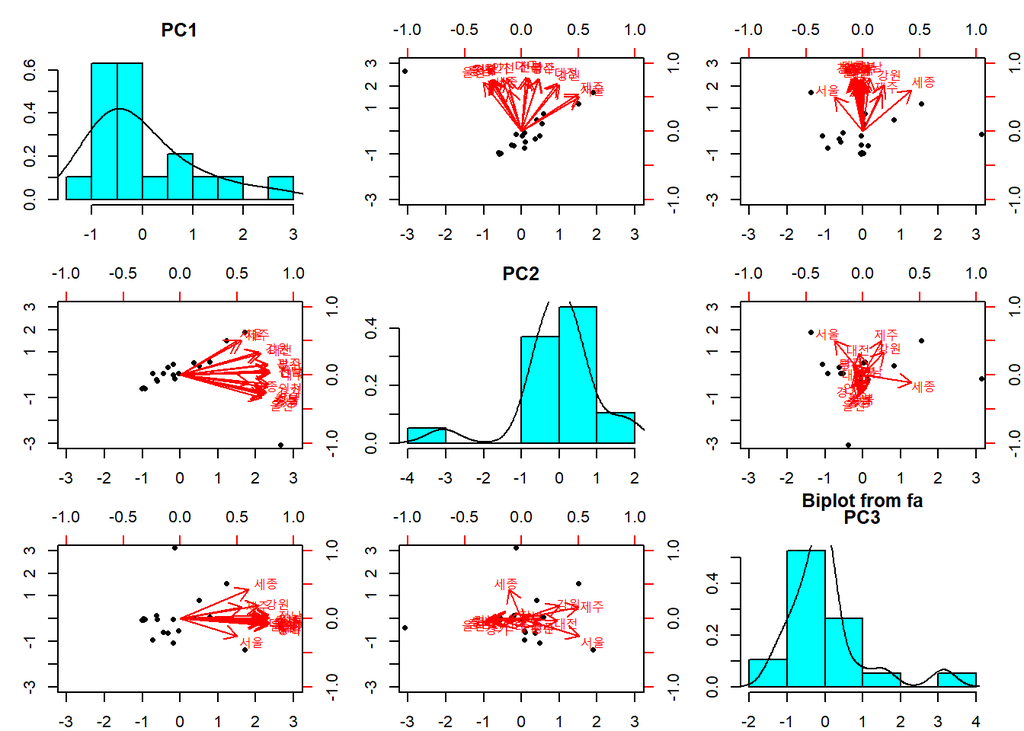

```r
biplot(work.factor2)
```

- 이를 bioplot으로 도출해보면 다음과 같다. 앞서 설명했듯이 각 변수간의 상관성이 너무 높기 때문에 해당 데이터는 요인분석을 실시하기에는 적절하지 않아보인다.

### (3) 이상치 시·도가 있는지 판단하시오.

```r
summary(workers_1[,-1])
```

```
##       강원             경기             경남             경북
##  Min.   :0.2150   Min.   : 0.016   Min.   : 0.029   Min.   : 0.0670
##  1st Qu.:0.8515   1st Qu.: 1.125   1st Qu.: 0.716   1st Qu.: 0.6695
##  Median :2.0750   Median : 2.072   Median : 1.614   Median : 1.5530
##  Mean   :3.0651   Mean   : 2.881   Mean   : 3.049   Mean   : 3.1514
##  3rd Qu.:5.3175   3rd Qu.: 3.529   3rd Qu.: 3.720   3rd Qu.: 4.1690
##  Max.   :9.5900   Max.   :13.977   Max.   :17.272   Max.   :17.3150
##       광주            대구             대전            부산
##  Min.   :0.003   Min.   :0.0000   Min.   :0.000   Min.   :0.003
##  1st Qu.:1.032   1st Qu.:0.8455   1st Qu.:1.207   1st Qu.:0.812
##  Median :2.242   Median :1.7940   Median :2.560   Median :2.046
##  Mean   :3.004   Mean   :2.7840   Mean   :2.948   Mean   :3.010
##  3rd Qu.:5.008   3rd Qu.:3.8415   3rd Qu.:4.777   3rd Qu.:4.243
##  Max.   :8.922   Max.   :9.8650   Max.   :8.447   Max.   :9.217
##       서울             세종            울산             인천
##  Min.   : 0.001   Min.   :0.005   Min.   : 0.017   Min.   : 0.009
##  1st Qu.: 1.571   1st Qu.:0.557   1st Qu.: 0.726   1st Qu.: 0.657
##  Median : 3.620   Median :1.734   Median : 1.688   Median : 1.699
##  Mean   : 3.762   Mean   :2.608   Mean   : 3.135   Mean   : 2.566
##  3rd Qu.: 5.205   3rd Qu.:3.741   3rd Qu.: 3.807   3rd Qu.: 3.578
##  Max.   :12.314   Max.   :8.878   Max.   :20.720   Max.   :11.413
##       전남             전북            제주              충남
##  Min.   :0.2110   Min.   :0.073   Min.   : 0.0320   Min.   : 0.049
##  1st Qu.:0.6545   1st Qu.:0.790   1st Qu.: 0.8675   1st Qu.: 0.686
##  Median :1.7320   Median :1.839   Median : 2.2940   Median : 2.049
##  Mean   :3.0294   Mean   :2.893   Mean   : 2.9879   Mean   : 3.305
##  3rd Qu.:4.9485   3rd Qu.:4.391   3rd Qu.: 3.5395   3rd Qu.: 4.170
##  Max.   :9.4460   Max.   :9.271   Max.   :12.4680   Max.   :20.171
##       충북
##  Min.   : 0.089
##  1st Qu.: 0.772
##  Median : 2.167
##  Mean   : 3.283
##  3rd Qu.: 4.351
##  Max.   :18.628
```

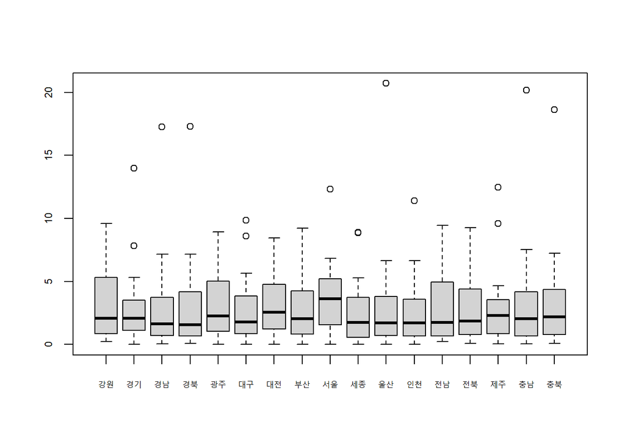

```r
boxplot(workers_1[,-1],cex.axis=0.7)
```

- 각 시도별로 이상치가 있는지 판단하기 위해 `summary()`함수와 상자그림을 이용해 살펴보았다. 결과를 살펴보면 한쪽으로 치우친 형태의 자료임을 확인할 수 있지만, 자료의 특성상 각 행은 산업별로 구분되기 때문에 섣불리 이상치라고 판단해서는 안된다고 보인다.

### (4) 요인분석 후 인자회전을 시키시오.

```r
work.factor4 = principal(workers_1[,-1], nfactors = 3, rotate = "varimax")
work.factor4
```

```
## Principal Components Analysis
## Call: principal(r = workers_1[, -1], nfactors = 3, rotate = "varimax")
## Standardized loadings (pattern matrix) based upon correlation matrix
##       RC1  RC2   RC3   h2     u2 com
## 강원 0.37 0.80  0.43 0.97 0.0285 2.0
## 경기 0.90 0.40  0.11 0.99 0.0117 1.4
## 경남 0.93 0.30  0.21 1.00 0.0043 1.3
## 경북 0.92 0.29  0.23 1.00 0.0039 1.3
## 광주 0.65 0.73  0.13 0.97 0.0282 2.0
## 대구 0.76 0.62  0.16 0.99 0.0100 2.0
## 대전 0.46 0.84  0.17 0.95 0.0523 1.7
## 부산 0.66 0.72  0.13 0.98 0.0218 2.0
## 서울 0.18 0.92 -0.16 0.90 0.0999 1.1
## 세종 0.56 0.26  0.71 0.88 0.1178 2.2
## 울산 0.96 0.20  0.15 0.99 0.0115 1.1
## 인천 0.87 0.44  0.17 0.98 0.0202 1.6
## 전남 0.70 0.63  0.30 0.97 0.0337 2.4
## 전북 0.71 0.63  0.25 0.97 0.0251 2.2
## 제주 0.11 0.87  0.36 0.90 0.0970 1.4
## 충남 0.95 0.25  0.19 0.99 0.0059 1.2
## 충북 0.94 0.28  0.21 1.00 0.0045 1.3
##
##                        RC1  RC2  RC3
## SS loadings           9.13 5.97 1.32
## Proportion Var        0.54 0.35 0.08
## Cumulative Var        0.54 0.89 0.97
## Proportion Explained  0.56 0.36 0.08
## Cumulative Proportion 0.56 0.92 1.00
##
## Mean item complexity =  1.7
## Test of the hypothesis that 3 components are sufficient.
##
## The root mean square of the residuals (RMSR) is  0.02
##  with the empirical chi square  1.68  with prob <  1
##
## Fit based upon off diagonal values = 1
```

- **h2**: 각 변수(시도)의 공통성(communality), 다른 변수들과의 공통성을 말하는 것으로 저 수치가 통상 0.3 보다 아래이면 다른 변수들과 공통점이 별로 없는 것으로 판단
- **u2**: 각 변수(시도)의 고유분산
- **Proportion var**: 각 요인이 설명 하는 총 분산의 비율을 말하는 것으로 RC1이 총 분산의 54%, RC2가 35%, RC3가 8%로 이 세 요인으로 총 변동의 97%를 설명한다 해석할 수 있다.
- RC1과, RC2의 수치를 확인해보면
  - RC1: 경기(0.9) 경남(0.93) 경북(0.92) 대구(0.76) 울산(0.96) 인천(0.87) 전남(0.7) 전북(0.71) 충남(0.95) 충북(0.94)
  - RC2: 강원(0.8) 광주(0.73) 대전(0.84) 부산(0.72) 서울(0.92) 제주(0.87)
  - RC3: 세종(0.71)

으로 나눌 수 있다. 각 요인에 대한 이름을 붙이기 위해서는 더 많은 정보가 필요한 것으로 판단된다.

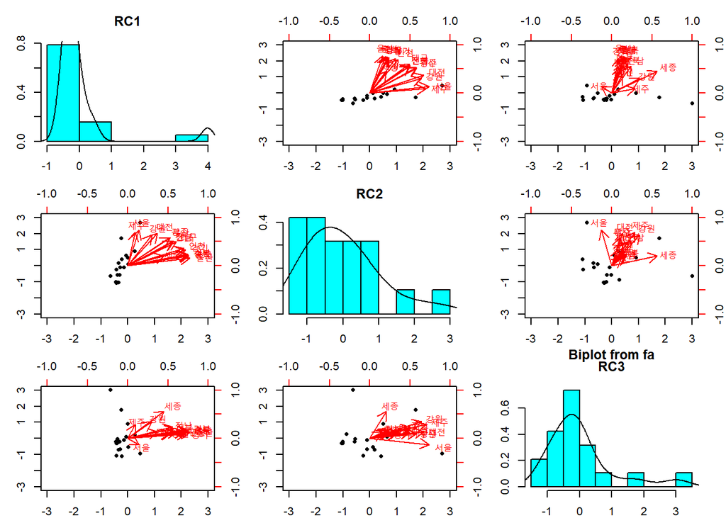

```r
biplot(work.factor4)
```

- 이를 bioplot으로 도출해보면 다음과 같다. 요인회전을 실시했으나 앞서 설명했듯이 각 변수간의 상관성이 너무 높기 때문에 해당 데이터는 요인분석을 실시하기에는 적절하지 않아보인다.

### (5) 요인분석 결과를 총평하시오.

- 시도별 산업 종사자 비율을 요인 분석을 수행하여 각 시 도별로 묶을 수 있는지 살펴보았다.
- 분석을 실시하기에 앞서, 변수(시도)별로 상관계수와 그래프를 통해 상관관계를 확인해 본 결과, 산업 종사자 비율은 시도별로 대체적으로 양의 상관관계를 가지고있음을 확인했다. 이는 요인 분석을 실시하는 데에 있어 중요하게 고려해야할 사항이며, 모든 변수의 상관관계가 높다는 것은 요인분석을 실시하기에 적절한 데이터가 아닐 수 도있다는 것을 의미한다고 보인다.
- 적절한 요인의 수를 확인하기 위해 주성분분석 방법으로 요인을 추출해본 결과, 고유근이 두번째까지가 1이 넘기 때문에 요인의 수를 2개 까지만 선택하는 것이 바람직하다고 보였다. 그러나 정보가 적기 때문에 요인 분석 후 해석의 용이성을 위해 요인의 수를 3으로 선택하여 요인 분석을 수행하였다.
- 요인의 수를 3으로 정하고 요인회전(직각회전, Varimax)을 통해 분산을 재분배시키는 단계를 거쳐 요인 분석을 실시해본 결과, RC1이 총 분산의 54%, RC2가 35%, RC3가 8%로 이 세 요인으로 총 변동의 97%를 설명한다 해석할 수 있다. 그러나 RC값으로 구분된 변수들의 적절한 특성을 발견하기가 어려워 각 요인에 대한 이름을 붙이기 위해서는 더 많은 정보가 필요한 것으로 판단된다.